# Advanced Machine Learning

The correction is available on this website : https://curiousml.github.io/

## PART 1 : Introduction to Python, Numpy, etc.

This part is an exploration of the popular packages in python : **NumPy** and **Matplotlib**

### 1.1. NumPy

```python
import numpy as np
```

**Q1.**

The chessboard can be generated as follows :

```python
A = np.zeros((8,8))
A[1::2, ::2] = 1
A[::2, 1::2] = 1
print(A)
```

```
[[0. 1. 0. 1. 0. 1. 0. 1.]
 [1. 0. 1. 0. 1. 0. 1. 0.]
 [0. 1. 0. 1. 0. 1. 0. 1.]
 [1. 0. 1. 0. 1. 0. 1. 0.]
 [0. 1. 0. 1. 0. 1. 0. 1.]
 [1. 0. 1. 0. 1. 0. 1. 0.]
 [0. 1. 0. 1. 0. 1. 0. 1.]
 [1. 0. 1. 0. 1. 0. 1. 0.]]
```

**Q2.**

The generation of the matrix can be coded as :

```python
# we choose the Fortran-like order and not the C-like order
M = np.arange(1, 21).reshape((4, 5), order='F')
print(M)
```

```
[[ 1  5  9 13 17]
 [ 2  6 10 14 18]
 [ 3  7 11 15 19]
 [ 4  8 12 16 20]]
```

The code for the extraction is the following :

```python
M[:,[1, -1, 2]][[1, 2, 0],:]
```

```
array([[ 6, 18, 10],
       [ 7, 19, 11],
       [ 5, 17,  9]])
```

### 1.2. Matplotlib

No question here, but you can run each line of code of the TP in order to become familiar with the package.

```python
import matplotlib.pyplot as plt
```

## 2. A problem of regression in dimension 1

### 2.1. Generating data

**Q3.** let us generate 15 real numbers drawn uniformly on $[-1, 1]$. These numbers define our array **x**

```python
import numpy as np

a = -1
b = 1
m = 15

x = a + (b - a) * np.random.random_sample(m)
print(x)
```

```
[-0.39390902  0.89747269  0.90545527  0.50289634 -0.40856984  0.56908429
  0.15090244 -0.77490045  0.15230838  0.88295381 -0.12795669  0.00553306
 -0.49691985 -0.20912397 -0.11364076]
```

**Q4.** *Let us define the array **y** defined by the tp*

```python
def g(x):
    return((3/2)*x**3 - x**2 -(3/4)*x + 1)

y = g(x) + (1/20)*np.random.randn(m)
```

**Q5.** *We are going to visualize in the plan the data created*

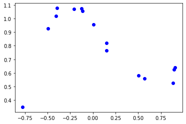

```python
plt.plot(x,y,'bo')
plt.show()
```

**small remark :** if we only observe this graph we can have an intuition of what family of predictors that corresponds. But (unfortunately ?) in reality, we rarely have a single descriptive feature.

**Q6.** With the same process, generate a sample test of size $m' = 30$ named $x_{test}$ and $y_{test}$

```python
m_test = 30
x_test = 2*np.random.random_sample(m_test)-1
y_test = g(x_test) + .05*np.random.randn(m_test)
```

### Linear regression

We define a predictor $f$ of linear regression to leas squares.

```python
from sklearn.linear_model import LinearRegression
f = LinearRegression()
```

The predictor needs a two dimensional descriptive data $X$ as input :

```python
X = x[:, np.newaxis]
X_test = x_test[:, np.newaxis]
```

Train our model :

```python
f.fit(X, y)
```

```
LinearRegression(copy_X=True, fit_intercept=True, n_jobs=None, normalize=False)
```

**Q7.** *Let's visualise the performance :*

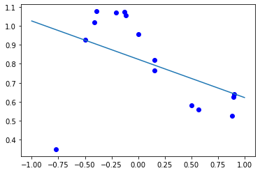

```python
xplot = np.linspace(-1,1,500).reshape(-1,1)
plt.plot(x,y,'bo')
plt.plot(xplot,f.predict(xplot))
plt.show()
```

**small remark 1 :** we can certainly do better...

**small remark 2 :** we can better evaluate the performance than visualy. Let's quantify the performance !

**Q8.** *We have the **mean error of train** and the **mean error of test** :*

```python
print("for train set :", sum((y-f.predict(X))**2)/m)
print("for test set :", sum((y_test-f.predict(X_test))**2)/m_test)
```

```
for train set : 0.04387573763782355
for test set : 0.2721722099874578
```

We remark that the predictor is much more accurate on the training set than the test set. It means that the predictor overfit on the training set.

### polynomial regression

**Q9.** *We are going to use a new predictor and see his performance. This time we are going to use a polynomial regression we degree 2*.

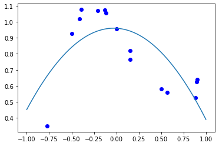

```
for train set : 0.025401588576239295
for test set : 0.13776741822876987
```

```python
## a
from sklearn.preprocessing import PolynomialFeatures
psi = PolynomialFeatures(2,include_bias=False).fit_transform

f = LinearRegression().fit(psi(X),y)

## b
plt.plot(x,y,'bo')
plt.plot(xplot,f.predict(psi(xplot)))
plt.show()

## c
print("for train set :", sum((y-f.predict(psi(X)))**2)/m)
print("for test set :", sum((y_test-f.predict(psi(X_test)))**2)/m_test)
```

We observe a boost in performance compared to the linear regression and we seem to overfit (on the data) less than linear regression.

**Q10.** *Let us generalize the computation to any maximum degree of polynomials $n\geq 1$*

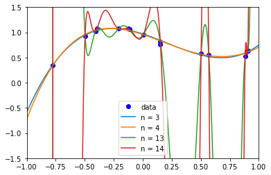

```
intercept for n = 3 0.969005648536144

coefficients for n = 3 [-0.7438228  -0.89003531  1.41314286]
```

```python
## a
def reg_poly(n):
    psi = PolynomialFeatures(n,include_bias=False).fit_transform
    return LinearRegression().fit(psi(X),y), psi

## b
plt.plot(x,y,'bo')
poly = {}
psi = {}
for n in [3,4,13,14]:
    poly[n], psi[n] = reg_poly(n)
    plt.plot(xplot,poly[n].predict(psi[n](xplot)))
plt.axis([-1, 1, -1.5, 1.5])
plt.legend(['data','n = 3', 'n = 4', 'n = 13', 'n = 14'])
plt.show()


## c
print("intercept for n = 3", poly[3].intercept_)
print()
print("coefficients for n = 3", poly[3].coef_)
```

For $n=3$, these coefficients seem to be similar to the coefficients of the function $g$.

d) For $n=14$, there is a polynomial that passes through each of the 15 points (Lagrange interpolation polynomial). This polynomial obviously minimizes the empirical risk, so it is the one given by the minimization of the empirical risk.

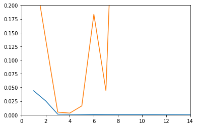

```python
## e
mean_train_error = []
mean_test_error = []
n_max = 14
for n in range(1,n_max+1):
    f, psi = reg_poly(n)
    mean_train_error.append(sum((f.predict(psi(X))-y)**2)/m)
    mean_test_error.append(sum((f.predict(psi(X_test))-y_test)**2)/m_test)

plt.plot(range(1,n_max+1),mean_train_error)
plt.plot(range(1,n_max+1),mean_test_error)
plt.axis([0, n_max, 0, .2])
plt.show()
```

The higher the $n$ is, the more complex the resulting polyomials are (and so the learning error is lower).

The test error decreases first. Then, when n is large, it increases: this is called **overfitting**. The high complexity of the polynomials makes it easier to stick to the learning points, but does not allow good generalization to new points.

### 2.4. Lasso regularization

**Q11.** *We know that with $n=14$, the predictor overfit the data. one of the most popular method for preventing overfitting is to desensitize your model to the training data with regularization like LASSO regularization. Let us view this more in details.*

```python
from sklearn.linear_model import Lasso

def reg_poly_lasso(n, alpha=1):
    psi = PolynomialFeatures(n,include_bias=False).fit_transform
    return Lasso(alpha).fit(psi(X),y), psi
```

```
Coefficients: [-0.89094501 -0.29205068  2.43654556 -2.06833419 -0.51013263  0.18547324
 -0.88167823  0.94417364 -0.76770884  1.19560602 -0.56352582  1.2686363
 -0.3326276   1.27475614]

Coefficients: [-0.86868022 -0.35395355  2.35093488 -1.78493925 -0.73123309  0.23673614
 -0.81187713  0.86136735 -0.46303073  0.88983557 -0.          0.65345108
  0.          0.88373619]

Coefficients: [-0.75200331 -0.73092878  1.45474651 -0.2220925  -0.         -0.
 -0.          0.         -0.          0.          0.          0.
  0.          0.        ]

Coefficients: [-0.67106039 -0.8437111   1.26927482 -0.          0.         -0.
  0.         -0.          0.         -0.          0.         -0.
  0.          0.        ]

Coefficients: [-0.02892989 -0.43296795  0.         -0.          0.         -0.
  0.          0.          0.          0.          0.          0.
  0.          0.        ]

Coefficients: [-0. -0. -0. -0. -0. -0. -0. -0. -0. -0. -0. -0. -0. -0.]

Coefficients: [-0. -0. -0. -0. -0. -0. -0. -0. -0. -0. -0. -0. -0. -0.]
```

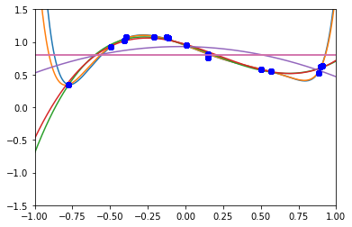

```python
for alpha in [10**a for a in range(-6,1)]:
    f, psi = reg_poly_lasso(14,alpha)
    plt.plot(x,y,'bo')
    plt.plot(xplot,f.predict(psi(xplot)))
    plt.axis([-1, 1, -1.5, 1.5])
    print('Coefficients:',f.coef_)
    print()
plt.show()
```

For large alpha values, the algorithm produces polynomials with many zero or close to zero coefficients. This limits the complexity of the polynomials and thus the overfitting.

**Q12. (Q13.)**

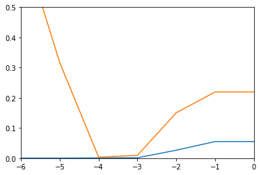

```python
mean_train_error = []
mean_test_error = []
nonzero_coefficients = []
degree = []
alpha_range = [10**a for a in range(-6,1)]

for alpha in alpha_range:
    f, psi = reg_poly_lasso(14,alpha)
    mean_train_error.append(sum((f.predict(psi(X))-y)**2)/m)
    mean_test_error.append(sum((f.predict(psi(X_test))-y_test)**2)/m_test)

plt.plot(np.log10(alpha_range),mean_train_error)
plt.plot(np.log10(alpha_range),mean_test_error)
plt.axis([-6,0,0,0.5])
plt.show()
```

The alpha parameter plays a role similar to n in question 10 (but in the opposite direction).

When alpha decreases, the polynomials obtained are more and more complex, and the learning error decreases. But when alpha is small enough, the test error increases again : there is overfitting.

## PART 2 : A first approach to SVM

```python
import numpy as np
import matplotlib.pyplot as plt

from sklearn.datasets import load_breast_cancer
data = load_breast_cancer()
X = data.data
y = data.target
```

**Q14.** *Let us split the data into training sample and test sample. We can simply use the sklearn.model_selection function* `train_test_split`

```python
from sklearn.model_selection import train_test_split
X_train, X_test, y_train, y_test = train_test_split(X,y)
# test train spit at 75% - 25%
```

**TEST : First, we are going to train a SVM and give his score on test sample as follows :**

```python
from sklearn.svm import LinearSVC
svm = LinearSVC(C=1).fit(X_train,y_train)
print('Score on test sample :', svm.score(X_test,y_test))
```

```
Score on test sample : 0.9370629370629371
```

**Q15.** *Let us train again a SVM predictor with the hyperparameter C calibrated with cross-validation*

```python
from sklearn.model_selection import validation_curve
C_range = np.logspace(-6,-2,50)
train_scores, valid_scores = validation_curve(LinearSVC(), X_train, y_train, "C", C_range, cv=10)
```

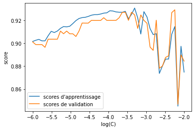

```python
train_scores_mean = np.mean(train_scores,axis=1)
valid_scores_mean = np.mean(valid_scores,axis=1)
plt.plot(np.log10(C_range),train_scores_mean,label="scores d'apprentissage")
plt.plot(np.log10(C_range),valid_scores_mean,label="scores de validation")
plt.legend()
plt.xlabel('log(C)')
plt.ylabel('score')
plt.show()
```

```python
C_best = C_range[np.argmax(valid_scores_mean)]
svm = LinearSVC(C=C_best).fit(X_train,y_train)
print('Score:', svm.score(X_test,y_test))
y_test_predict = svm.predict(X_test)
```

```
Score: 0.916083916083916
```

for more information on the hyperparameter C : https://stats.stackexchange.com/questions/31066/what-is-the-influence-of-c-in-svms-with-linear-kernel

**Q16.** *Compute the precision and recall from the coefficients of the confusion matrix :*

- generation of the confusion matrix :

```python
from sklearn.metrics import confusion_matrix
confusion_matrix_test = confusion_matrix(y_test,y_test_predict)
print(confusion_matrix_test)
```

```
[[50  5]
 [ 7 81]]
```

- the metrics recall and precision (directly given by **with confusion matrix**) :

```python
tp = confusion_matrix_test[0,0]
fp = confusion_matrix_test[1,0]
fn = confusion_matrix_test[0,1]
recall = tp/(tp+fn)
precision = tp/(tp+fp)
print('Recall :', recall)
print('Precision :', precision)
```

```
Recall : 0.9090909090909091
Precision : 0.8771929824561403
```

- the metrics recall and precision (directly given by **with sklearn package**) :

```python
from sklearn.metrics import recall_score, precision_score
print('Recall: ',recall_score(y_test,y_test_predict,pos_label=0))
print('Precision: ',precision_score(y_test,y_test_predict,pos_label=0))
```

```
Recall:  0.9090909090909091
Precision:  0.8771929824561403
```

**Q17.** *We are going to define a function `false_positive_rate`*

```python
def false_positive_rate(y_true,y_predict,pos_label):
    return np.sum(y_true[y_predict == pos_label] != pos_label)/np.sum(y_true != pos_label)

print(false_positive_rate(y_test,y_test_predict,0))
```

```
0.07954545454545454
```

**Q18.** *Define the function `modified_predictor`*

```python
def modified_predictor(X,tau):
    return (svm.decision_function(X) >= tau).astype('int')
```

**Q19.**

- A very **poor** predictor has a recall (true positive rate) only slightly higher than the false positive rate : the ROC curve is therefore only slightly above the diagonal (coordinate curve $(t,t)$ for $t∈[0.1]$).
- For a **good** predictor on the other hand, the ROC curve goes well above the diagonal.

[figure not shown]

**Q20.** *Let us find the minimum and maximum values for $\tau$ and trace the corresponding ROC curve*

```python
decision_function_train = svm.decision_function(X_train)
tau_range = np.linspace(np.min(decision_function_train),np.max(decision_function_train),100)
```

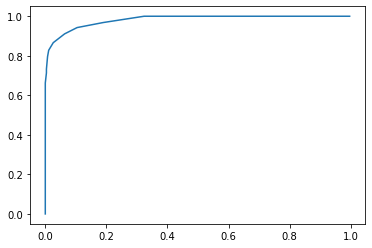

```python
recalls = []
fprs = []
for tau in tau_range:
    y_train_predict = modified_predictor(X_train,tau)
    recalls.append(recall_score(y_train,y_train_predict,pos_label=0))
    fprs.append(false_positive_rate(y_train,y_train_predict,0))

plt.plot(fprs,recalls)
plt.show()
```

**Q21.** *Let us determine the $\tau$ that gives a better recall :*

```python
recalls_array = np.array(recalls)
fprs_array = np.array(fprs)

good_enough_recalls_index = (recalls_array >= .95)
tau_best = (tau_range[good_enough_recalls_index])[np.argmin(fprs_array[good_enough_recalls_index])]

y_test_predict = modified_predictor(X_test,tau_best)

from sklearn.metrics import accuracy_score
print('Accuracy score: ', accuracy_score(y_test, y_test_predict))
print('Recall: ', recall_score(y_test, y_test_predict,pos_label=0))
print('Precision: ', precision_score(y_test, y_test_predict,pos_label=0))
print('False positive rate: ', false_positive_rate(y_test, y_test_predict,pos_label=0))
```

```
Accuracy score:  0.8881118881118881
Recall:  0.9454545454545454
Precision:  0.8
False positive rate:  0.14772727272727273
```

## PART 3 : Learning and selection of SVM

```python
import numpy as np # to manipulate numerical values
import pandas as pd # to manipulate dataframes
import matplotlib.pyplot as plt # to display graphics
import seaborn as sns # graphic specially made for data vizualization
```

Let us prepare the dataset :

```python
data = pd.read_csv("wine_dataset.csv", sep = ";")
data.head(5)
```

|  | fixed acidity | volatile acidity | citric acid | residual sugar | chlorides | free sulfur dioxide | total sulfur dioxide | density | pH | sulphates | alcohol | quality | color |
| --- | --- | --- | --- | --- | --- | --- | --- | --- | --- | --- | --- | --- | --- |
| 0 | 7.0 | 0.27 | 0.36 | 20.7 | 0.045 | 45.0 | 170.0 | 1.0010 | 3.00 | 0.45 | 8.8 | 6 | 0 |
| 1 | 6.3 | 0.30 | 0.34 | 1.6 | 0.049 | 14.0 | 132.0 | 0.9940 | 3.30 | 0.49 | 9.5 | 6 | 0 |
| 2 | 8.1 | 0.28 | 0.40 | 6.9 | 0.050 | 30.0 | 97.0 | 0.9951 | 3.26 | 0.44 | 10.1 | 6 | 0 |
| 3 | 7.2 | 0.23 | 0.32 | 8.5 | 0.058 | 47.0 | 186.0 | 0.9956 | 3.19 | 0.40 | 9.9 | 6 | 0 |
| 4 | 7.2 | 0.23 | 0.32 | 8.5 | 0.058 | 47.0 | 186.0 | 0.9956 | 3.19 | 0.40 | 9.9 | 6 | 0 |

This data contains :

```python
print(data.shape)
```

```
(6497, 13)
```

6497 examples (rows) and 13 features (columns).

The new data is the following :

```python
from sklearn.preprocessing import MinMaxScaler

X = data[["chlorides", "total sulfur dioxide"]]
y = data["color"]
X = MinMaxScaler(feature_range=(-1, 1)).fit(X).transform(X)
print(X[:5,])
print(y[:5])
```

```
[[-0.88039867 -0.24423963]
 [-0.86710963 -0.41935484]
 [-0.86378738 -0.58064516]
 [-0.8372093  -0.17050691]
 [-0.8372093  -0.17050691]]
0    0
1    0
2    0
3    0
4    0
Name: color, dtype: int64
```

**Q22.** *Separate the dataset into a training and a test set*

```python
X_train, X_test, y_train, y_test = train_test_split(X, y)
```

We will first perform a logistic regression.

```python
from sklearn.linear_model import LogisticRegressionCV
```

**Q23.** *Let's display its score on the test sample*

```python
logreg = LogisticRegressionCV(cv=5, Cs = np.logspace(-6,6,20)).fit(X_train, y_train)
logreg.score(X_test, y_test)
```

```
0.9483076923076923
```

Since we only have two explanatory variables, we can represent in the plan the inputs, as well as the boundary of logreg predictor decision.

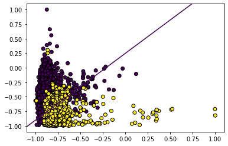

```python
plt.scatter(X[:,0],X[:,1],c=y,edgecolors='k')
figure = plt.gca()
xlim = figure.get_xlim()
ylim = figure.get_ylim()
xx = np.linspace(xlim[0], xlim[1], 100)
yy = np.linspace(ylim[0], ylim[1], 100)
YY, XX = np.meshgrid(yy, xx)
xy = np.vstack([XX.ravel(), YY.ravel()]).T
P = logreg.decision_function(xy).reshape(XX.shape)
plt.contour(XX, YY, P, levels=[0], alpha=1)
plt.show()
```

**Q24.** *Let us define the function `plot_decision_boundary`*

```python
def plot_decision_boundary(predictor):
    fig, ax = plt.subplots()
    ax.scatter(X[:,0],X[:,1],c=y,edgecolors='k')
    xlim = ax.get_xlim()
    ylim = ax.get_ylim()
    xx = np.linspace(xlim[0], xlim[1], 100)
    yy = np.linspace(ylim[0], ylim[1], 100)
    YY, XX = np.meshgrid(yy, xx)
    xy = np.vstack([XX.ravel(), YY.ravel()]).T
    P = predictor.decision_function(xy).reshape(XX.shape)
    ax.contour(XX, YY, P, levels=[0], alpha=1)
    return None
```

[output not shown]

[output not shown]

[output not shown]

[output cut: 9 more lines]

[output not shown]

[output not shown]

[output not shown]

[output not shown]

[output not shown]

[output not shown]

[output not shown]

[output not shown]

[output not shown]

[output not shown]

[output not shown]

[output not shown]

[output not shown]

[output not shown]

[output not shown]

[output not shown]

[output not shown]

[output not shown]

[output not shown]

[output not shown]

```
Score : 0.9489230769230769
```

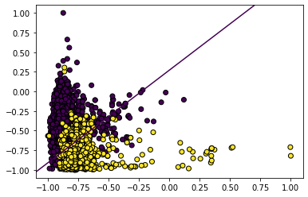

```python
from sklearn.model_selection import GridSearchCV
from sklearn.svm import LinearSVC
grid = {'C':np.logspace(-6,6,20)}
svc = GridSearchCV(LinearSVC(),cv=5,param_grid=grid,verbose=2)
print('Score :',svc.fit(X_train,y_train).score(X_test,y_test))
plot_decision_boundary(svc)
```

```python
print(svc.best_params_)
```

```
{'C': 37.92690190732246}
```

As shown by the plot, we can propose an improvement by using SVMs with kernels.

**Q25.** *SVM with polynomial kernels*

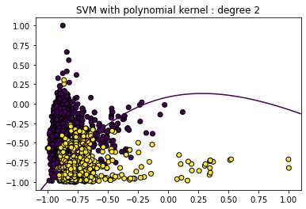

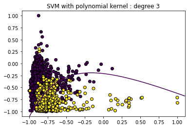

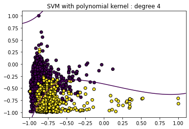

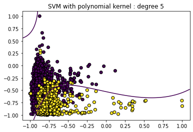

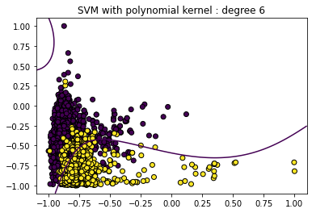

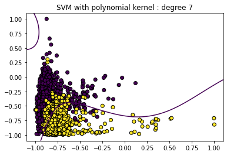

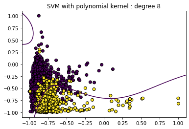

```python
from sklearn.svm import SVC

svcpoly = dict()
for d in range(2, 9):
    svcpoly[d] = SVC(kernel = "poly", C=1, coef0=1, degree=d, gamma="auto").fit(X_train, y_train)
    plot_decision_boundary(svcpoly[d])
    plt.title("SVM with polynomial kernel : degree " + str(d))
```

visually, svm with polynomial kernel whose degree is 3 (or maybe 4) seems to be a good predictor. Let us quantify this observation.

**Q26.** *train a kernel SVM polynomial with degree as hyperparameter to tune by CV (using GridSearchCV)*

[output not shown]

[output not shown]

[output not shown]

[output not shown]

```
Score : 0.9636923076923077
```

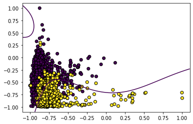

```python
from sklearn.model_selection import GridSearchCV
from sklearn.svm import SVC
grid = {'degree':np.arange(2,9)}
svc = GridSearchCV(SVC(kernel="poly",C=1,coef0=1,gamma="auto"),cv=5,param_grid=grid,verbose=2)
print('Score :',svc.fit(X_train,y_train).score(X_test,y_test))
plot_decision_boundary(svc)
```

```python
svc.get_params
```

```
<bound method BaseEstimator.get_params of GridSearchCV(cv=5, error_score=nan,
             estimator=SVC(C=1, break_ties=False, cache_size=200,
                           class_weight=None, coef0=1,
                           decision_function_shape='ovr', degree=3,
                           gamma='auto', kernel='poly', max_iter=-1,
                           probability=False, random_state=None, shrinking=True,
                           tol=0.001, verbose=False),
             iid='deprecated', n_jobs=None,
             param_grid={'degree': array([2, 3, 4, 5, 6, 7, 8])},
             pre_dispatch='2*n_jobs', refit=True, return_train_score=False,
             scoring=None, verbose=2)>
```